# Exploring IBR-MRT output

Nic Rivers

## Set-up

This deck describes preliminary outputs from the CGE-IBR-MRT package.

## Motivation

With unilateral implementation of a carbon price, policy makers face competing pressures:

- they want to achieve significant emission reductions
- they want to avoid carbon leakage
- they want to keep the carbon price low
- they want to maintain the competitiveness of domestic industry

## Model set up

- We analyze using a multi-region CGE model.
- One region unilaterally implements a carbon price. Other regions do not.
- We consider alternative forms of rebating carbon pricing revenues.
- We consider carbon prices that differ from the *social cost of carbon*.
- We analyze both welfare in the implementing region as well as carbon leakage.

## Simulation #1 - carbon price in USA is set at SCC ($100/t)

Output-based rebating and lump sum rebating produce largest welfare gains.

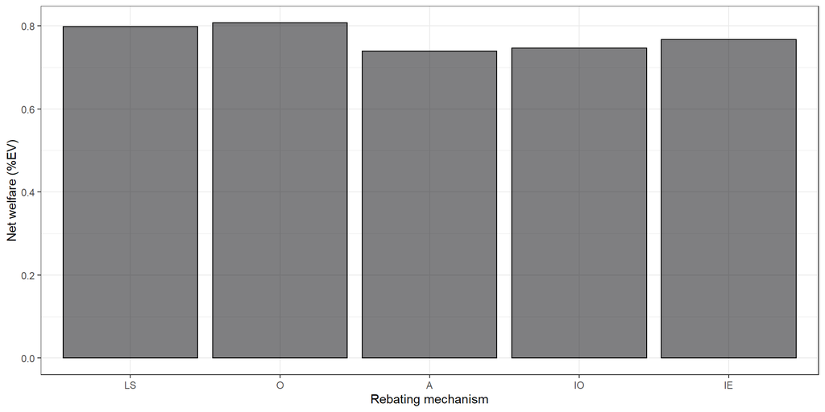

Net welfare is Hicksian equivalent variation in income for the implementing region. It includes welfare gains from reduced emissions at the (global) social cost of carbon.

## Simulation #2 - carbon price in USA ($25/t) is set below SCC ($250/t)

Policies that rebate to reward emission reduction achieve welfare gains.

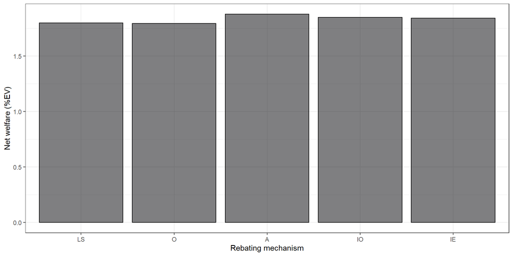

Net welfare is Hicksian equivalent variation in income for the implementing region. It includes welfare gains from reduced emissions at the (global) social cost of carbon.

## Comparing IBOR to OBR

If carbon price is set sufficiently below SCC, IBOR achieves higher welfare than OBR.

[figure not shown]

## Emissions leakage

Output-based rebates have lowest emission leakage

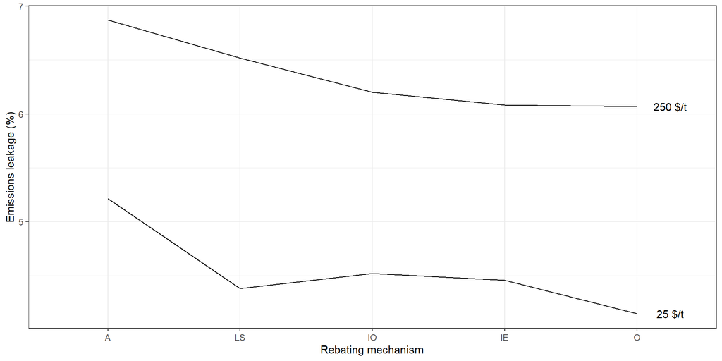

Figure shows international emission leakage following USA implementation of carbon price at level indicated in figure using different rebating mechanisms for EITE sectors.

## Employment

Intensity-based policies have lowest impact on employment.

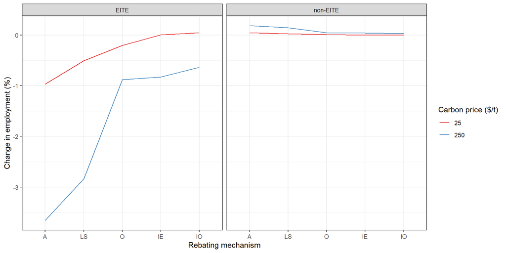

## A theoretical model

It would be useful to have a theoretical model to explore these results. Desirable model characteristics:

- General equilibrium model
- Home and foreign producers both represented
- EITE and non-EITE sectors both represented. EITE sector is traded, non-EITE sector is non-traded. Both sectors use labour and emissions to produce output.
- Consumers in each region consume EITE goods, non-EITE goods, government services, and labour.
- Government gets revenue from emission tax, income (labour) tax, EITE output tax. Reforms are budget neutral.
- Emission tax can differ from social cost of carbon.
- Derive welfare change/leakage/employment in home associated with carbon price and different rebating options.